# **Prediction of Profit**

### **Verzeo - Data Science - Minor Project**

**Name:** Aashish Bansal  
**Email:** aashish22bansal@gmail.com  
**Program:** Data Science October  
**Project Description:** Perform regression analysis to predict the profit of each the 50 startups mentioned in the dataset by taking all the input parameters(multi linear regression).  
**Dataset Link:** https://raw.githubusercontent.com/arib168/data/main/50_Startups.csv

# Importing Libraries

```python
import pandas as pd
import numpy as np
import matplotlib.pyplot as plt
import seaborn as sns
import sklearn
```

# Importing Dataset

```python
file_path = "https://raw.githubusercontent.com/arib168/data/main/50_Startups.csv"
```

```python
data=pd.read_csv(file_path)
```

```python
data
```

|  | R&D Spend | Administration | Marketing Spend | State | Profit |
| --- | --- | --- | --- | --- | --- |
| 0 | 165349.20 | 136897.80 | 471784.10 | New York | 192261.83 |
| 1 | 162597.70 | 151377.59 | 443898.53 | California | 191792.06 |
| 2 | 153441.51 | 101145.55 | 407934.54 | Florida | 191050.39 |
| 3 | 144372.41 | 118671.85 | 383199.62 | New York | 182901.99 |
| 4 | 142107.34 | 91391.77 | 366168.42 | Florida | 166187.94 |
| 5 | 131876.90 | 99814.71 | 362861.36 | New York | 156991.12 |
| 6 | 134615.46 | 147198.87 | 127716.82 | California | 156122.51 |
| 7 | 130298.13 | 145530.06 | 323876.68 | Florida | 155752.60 |
| 8 | 120542.52 | 148718.95 | 311613.29 | New York | 152211.77 |
| 9 | 123334.88 | 108679.17 | 304981.62 | California | 149759.96 |
| 10 | 101913.08 | 110594.11 | 229160.95 | Florida | 146121.95 |
| 11 | 100671.96 | 91790.61 | 249744.55 | California | 144259.40 |
| 12 | 93863.75 | 127320.38 | 249839.44 | Florida | 141585.52 |
| 13 | 91992.39 | 135495.07 | 252664.93 | California | 134307.35 |
| 14 | 119943.24 | 156547.42 | 256512.92 | Florida | 132602.65 |
| 15 | 114523.61 | 122616.84 | 261776.23 | New York | 129917.04 |
| 16 | 78013.11 | 121597.55 | 264346.06 | California | 126992.93 |
| 17 | 94657.16 | 145077.58 | 282574.31 | New York | 125370.37 |
| 18 | 91749.16 | 114175.79 | 294919.57 | Florida | 124266.90 |
| 19 | 86419.70 | 153514.11 | 0.00 | New York | 122776.86 |
| 20 | 76253.86 | 113867.30 | 298664.47 | California | 118474.03 |
| 21 | 78389.47 | 153773.43 | 299737.29 | New York | 111313.02 |
| 22 | 73994.56 | 122782.75 | 303319.26 | Florida | 110352.25 |
| 23 | 67532.53 | 105751.03 | 304768.73 | Florida | 108733.99 |
| 24 | 77044.01 | 99281.34 | 140574.81 | New York | 108552.04 |
| 25 | 64664.71 | 139553.16 | 137962.62 | California | 107404.34 |
| 26 | 75328.87 | 144135.98 | 134050.07 | Florida | 105733.54 |
| 27 | 72107.60 | 127864.55 | 353183.81 | New York | 105008.31 |
| 28 | 66051.52 | 182645.56 | 118148.20 | Florida | 103282.38 |
| 29 | 65605.48 | 153032.06 | 107138.38 | New York | 101004.64 |
| 30 | 61994.48 | 115641.28 | 91131.24 | Florida | 99937.59 |
| 31 | 61136.38 | 152701.92 | 88218.23 | New York | 97483.56 |
| 32 | 63408.86 | 129219.61 | 46085.25 | California | 97427.84 |
| 33 | 55493.95 | 103057.49 | 214634.81 | Florida | 96778.92 |
| 34 | 46426.07 | 157693.92 | 210797.67 | California | 96712.80 |
| 35 | 46014.02 | 85047.44 | 205517.64 | New York | 96479.51 |
| 36 | 28663.76 | 127056.21 | 201126.82 | Florida | 90708.19 |
| 37 | 44069.95 | 51283.14 | 197029.42 | California | 89949.14 |
| 38 | 20229.59 | 65947.93 | 185265.10 | New York | 81229.06 |
| 39 | 38558.51 | 82982.09 | 174999.30 | California | 81005.76 |
| 40 | 28754.33 | 118546.05 | 172795.67 | California | 78239.91 |
| 41 | 27892.92 | 84710.77 | 164470.71 | Florida | 77798.83 |
| 42 | 23640.93 | 96189.63 | 148001.11 | California | 71498.49 |
| 43 | 15505.73 | 127382.30 | 35534.17 | New York | 69758.98 |
| 44 | 22177.74 | 154806.14 | 28334.72 | California | 65200.33 |
| 45 | 1000.23 | 124153.04 | 1903.93 | New York | 64926.08 |
| 46 | 1315.46 | 115816.21 | 297114.46 | Florida | 49490.75 |
| 47 | 0.00 | 135426.92 | 0.00 | California | 42559.73 |
| 48 | 542.05 | 51743.15 | 0.00 | New York | 35673.41 |
| 49 | 0.00 | 116983.80 | 45173.06 | California | 14681.40 |

# Basic Data Analysis

## Viewing the Data

```python
data.head()
```

|  | R&D Spend | Administration | Marketing Spend | State | Profit |
| --- | --- | --- | --- | --- | --- |
| 0 | 165349.20 | 136897.80 | 471784.10 | New York | 192261.83 |
| 1 | 162597.70 | 151377.59 | 443898.53 | California | 191792.06 |
| 2 | 153441.51 | 101145.55 | 407934.54 | Florida | 191050.39 |
| 3 | 144372.41 | 118671.85 | 383199.62 | New York | 182901.99 |
| 4 | 142107.34 | 91391.77 | 366168.42 | Florida | 166187.94 |

```python
data.tail()
```

|  | R&D Spend | Administration | Marketing Spend | State | Profit |
| --- | --- | --- | --- | --- | --- |
| 45 | 1000.23 | 124153.04 | 1903.93 | New York | 64926.08 |
| 46 | 1315.46 | 115816.21 | 297114.46 | Florida | 49490.75 |
| 47 | 0.00 | 135426.92 | 0.00 | California | 42559.73 |
| 48 | 542.05 | 51743.15 | 0.00 | New York | 35673.41 |
| 49 | 0.00 | 116983.80 | 45173.06 | California | 14681.40 |

## Numerical/Statistical analysis of the dataset

```python
data.describe()
```

|  | R&D Spend | Administration | Marketing Spend | Profit |
| --- | --- | --- | --- | --- |
| count | 50.000000 | 50.000000 | 50.000000 | 50.000000 |
| mean | 73721.615600 | 121344.639600 | 211025.097800 | 112012.639200 |
| std | 45902.256482 | 28017.802755 | 122290.310726 | 40306.180338 |
| min | 0.000000 | 51283.140000 | 0.000000 | 14681.400000 |
| 25% | 39936.370000 | 103730.875000 | 129300.132500 | 90138.902500 |
| 50% | 73051.080000 | 122699.795000 | 212716.240000 | 107978.190000 |
| 75% | 101602.800000 | 144842.180000 | 299469.085000 | 139765.977500 |
| max | 165349.200000 | 182645.560000 | 471784.100000 | 192261.830000 |

## Dimensions of dataset

```python
print("Number of Rows in Dataset: {rows}".format(rows=data.shape[0]))
print("Number of Columns in Dataset: {cols}".format(cols=data.shape[1]))
```

```
Number of Rows in Dataset: 50
Number of Columns in Dataset: 5
```

## Duplicate Values

Here we are trying to check if there are repeated values in the dataset or not.

```python
print("Number of Dulplicate values: {duplicates}".format(duplicates=data.duplicated().sum()))
```

```
Number of Dulplicate values: 0
```

**Inference:** There are no duplicate values.

## Check for NULL values

Here, we will check if there are any mising values in the dataset or not.

```python
print("Number of Null values in Each Column:\n")
data.isnull().sum()
```

```
Number of Null values in Each Column:
```

```
R&D Spend          0
Administration     0
Marketing Spend    0
State              0
Profit             0
dtype: int64
```

**Inference:** There are no null values in the dataset.

## Schema of dataset

```python
data.info()
```

```
<class 'pandas.core.frame.DataFrame'>
RangeIndex: 50 entries, 0 to 49
Data columns (total 5 columns):
 #   Column           Non-Null Count  Dtype
---  ------           --------------  -----
 0   R&D Spend        50 non-null     float64
 1   Administration   50 non-null     float64
 2   Marketing Spend  50 non-null     float64
 3   State            50 non-null     object
 4   Profit           50 non-null     float64
dtypes: float64(4), object(1)
memory usage: 2.1+ KB
```

# Exploratory Data Analysis

## Correlation matrix

First we will find the Correlation between the columns of the dataset.

```python
correlation = data.corr()
```

```python
correlation
```

|  | R&D Spend | Administration | Marketing Spend | Profit |
| --- | --- | --- | --- | --- |
| R&D Spend | 1.000000 | 0.241955 | 0.724248 | 0.972900 |
| Administration | 0.241955 | 1.000000 | -0.032154 | 0.200717 |
| Marketing Spend | 0.724248 | -0.032154 | 1.000000 | 0.747766 |
| Profit | 0.972900 | 0.200717 | 0.747766 | 1.000000 |

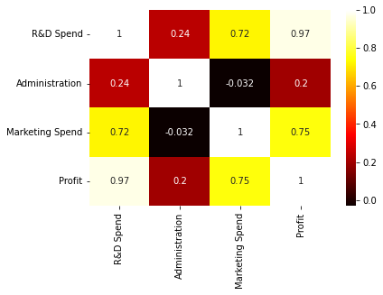

```python
sns.heatmap(correlation, annot=True, cmap='hot')
plt.show()
```

**Inference:** Here we can see the direct correlation with profit from how it is shown in the heatmap of the correlation plot.

## Outliers detection in the target variable

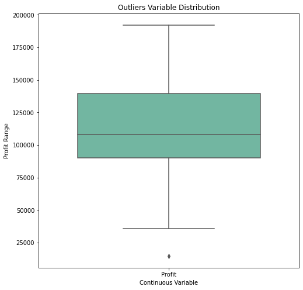

```python
outliers = ['Profit']
plt.rcParams['figure.figsize'] = [8,8]
sns.boxplot(data=data[outliers], orient="v", palette="Set2" , width=0.7)
plt.title("Outliers Variable Distribution")
plt.ylabel("Profit Range")
plt.xlabel("Continuous Variable")
plt.show()
```

**Inference:** While looking at the boxplot we can see the outliers in the profit(target variable), but the amount of data is not much as we have been provided with a dataset which has just 50 entries. So, it won’t really create much negative impact.

## State-wise outliers detection

Checking the States in the dataset.

```python
data["State"].unique()
```

```
array(['New York', 'California', 'Florida'], dtype=object)
```

**Inference:** There are three unique States in the dataset.

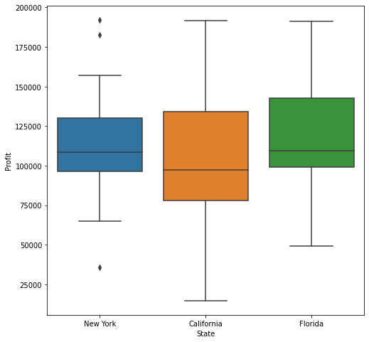

```python
sns.boxplot(x='State', y='Profit', data=data)
plt.show()
```

## Histogram on Profit

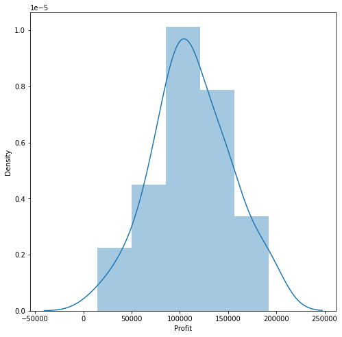

```python
sns.distplot(data['Profit'], bins=5, kde=True)
plt.show()
```

**Inference:** The average profit (which is 100k) is the most frequent i.e. this should be in the category of distribution plot.

## Pair plot

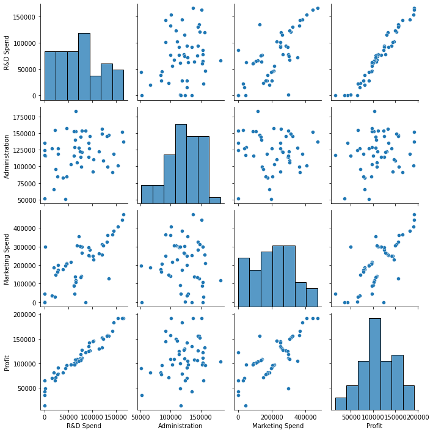

```python
sns.pairplot(data)
plt.show()
```

**Inference:**

# Individual Column Analysis using Correlation

## R&D vs Profit

Lets Analyse the relationship between Dependent variable with other independent variable...

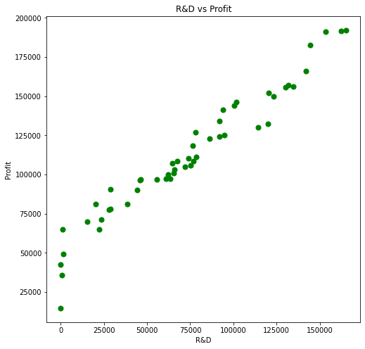

```python
#Plot R&D vs Profit............
x1 = data.iloc[:, 0].values
y1 = data.iloc[:, -1].values
plt.scatter(x1, y1, color='Green', s=50)
plt.xlabel('R&D')
plt.ylabel('Profit')
plt.title('R&D vs Profit')
plt.show()
```

From the above plot we can able to visualize that R&D and Profit has positive correlation.

## Administration vs Profit

Lets Analyse the relationship between Administration and Profit

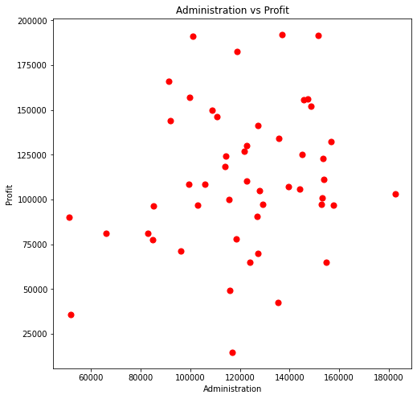

```python
x1 = data.iloc[:, 1].values
y1 = data.iloc[:, -1].values
plt.scatter(x1, y1, color='Red', s=50)
plt.xlabel('Administration')
plt.ylabel('Profit')
plt.title('Administration vs Profit')
plt.show()
```

## Marketing Spend vs Profit

Lets Analyse the relationship between Marketing Spend and Profit

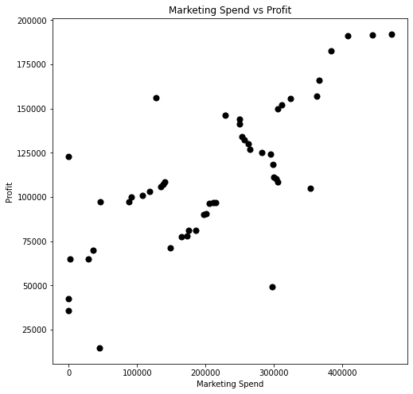

```python
#Plot Marketing Spend vs Profit
x1 = data.iloc[:, 2].values
y1 = data.iloc[:, -1].values
plt.scatter(x1, y1, color='Black', s=50)
plt.xlabel('Marketing Spend')
plt.ylabel('Profit')
plt.title('Marketing Spend vs Profit')
plt.show()
```

From above plot, there is a correlation between Marketing Spend and Profit.

## State vs Profit

Lets Analyse the relationship between Marketing State and Profit...

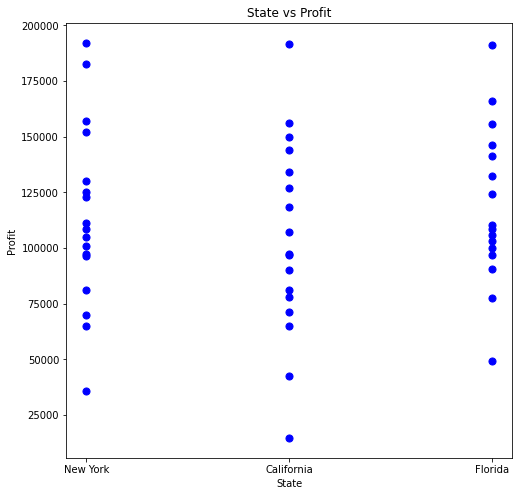

```python
#Plot State vs Profit
x1 = data.iloc[:, 3].values
y1 = data.iloc[:, -1].values
plt.scatter(x1, y1, color='Blue', s=50)
plt.xlabel('State')
plt.ylabel('Profit')
plt.title('State vs Profit')
plt.show()
```

Since state consists strings so it doesn't shows correlation so we can not know does it affects or not. So, let's try to convert it to integers and then analyse again.

```python
from numpy import array
from numpy import argmax
from sklearn.preprocessing import LabelEncoder
from sklearn.preprocessing import OneHotEncoder
```

```python
# define example
new_data = data["State"]#['New York', 'California', 'Florida']
values = array(new_data)
print(values)
```

```
['New York' 'California' 'Florida' 'New York' 'Florida' 'New York'
 'California' 'Florida' 'New York' 'California' 'Florida' 'California'
 'Florida' 'California' 'Florida' 'New York' 'California' 'New York'
 'Florida' 'New York' 'California' 'New York' 'Florida' 'Florida'
 'New York' 'California' 'Florida' 'New York' 'Florida' 'New York'
 'Florida' 'New York' 'California' 'Florida' 'California' 'New York'
 'Florida' 'California' 'New York' 'California' 'California' 'Florida'
 'California' 'New York' 'California' 'New York' 'Florida' 'California'
 'New York' 'California']
```

```python
# integer encode
label_encoder = LabelEncoder()
integer_encoded = label_encoder.fit_transform(values)
print(integer_encoded)
```

```
[2 0 1 2 1 2 0 1 2 0 1 0 1 0 1 2 0 2 1 2 0 2 1 1 2 0 1 2 1 2 1 2 0 1 0 2 1
 0 2 0 0 1 0 2 0 2 1 0 2 0]
```

```python
# binary encode
onehot_encoder = OneHotEncoder(sparse=False)
integer_encoded = integer_encoded.reshape(len(integer_encoded), 1)
onehot_encoded = onehot_encoder.fit_transform(integer_encoded)
print(onehot_encoded)
```

```
[[0. 0. 1.]
 [1. 0. 0.]
 [0. 1. 0.]
 [0. 0. 1.]
 [0. 1. 0.]
 [0. 0. 1.]
 [1. 0. 0.]
 [0. 1. 0.]
 [0. 0. 1.]
 [1. 0. 0.]
 [0. 1. 0.]
 [1. 0. 0.]
 [0. 1. 0.]
 [1. 0. 0.]
 [0. 1. 0.]
 [0. 0. 1.]
 [1. 0. 0.]
 [0. 0. 1.]
 [0. 1. 0.]
 [0. 0. 1.]
 [1. 0. 0.]
 [0. 0. 1.]
 [0. 1. 0.]
 [0. 1. 0.]
 [0. 0. 1.]
 [1. 0. 0.]
 [0. 1. 0.]
 [0. 0. 1.]
 [0. 1. 0.]
 [0. 0. 1.]
 [0. 1. 0.]
 [0. 0. 1.]
 [1. 0. 0.]
 [0. 1. 0.]
 [1. 0. 0.]
 [0. 0. 1.]
 [0. 1. 0.]
 [1. 0. 0.]
 [0. 0. 1.]
 [1. 0. 0.]
 [1. 0. 0.]
 [0. 1. 0.]
 [1. 0. 0.]
 [0. 0. 1.]
 [1. 0. 0.]
 [0. 0. 1.]
 [0. 1. 0.]
 [1. 0. 0.]
 [0. 0. 1.]
 [1. 0. 0.]]
```

```python
# invert first example
inverted = label_encoder.inverse_transform([argmax(onehot_encoded[0, :])])
print(inverted)
```

```
['New York']
```

```python
#Plot State vs Profit
x1 = integer_encoded
x1.shape
```

```
(50, 1)
```

```python
y1 = data.iloc[:, -1].values
y1
```

```
array([192261.83, 191792.06, 191050.39, 182901.99, 166187.94, 156991.12,
       156122.51, 155752.6 , 152211.77, 149759.96, 146121.95, 144259.4 ,
       141585.52, 134307.35, 132602.65, 129917.04, 126992.93, 125370.37,
       124266.9 , 122776.86, 118474.03, 111313.02, 110352.25, 108733.99,
       108552.04, 107404.34, 105733.54, 105008.31, 103282.38, 101004.64,
        99937.59,  97483.56,  97427.84,  96778.92,  96712.8 ,  96479.51,
        90708.19,  89949.14,  81229.06,  81005.76,  78239.91,  77798.83,
        71498.49,  69758.98,  65200.33,  64926.08,  49490.75,  42559.73,
        35673.41,  14681.4 ])
```

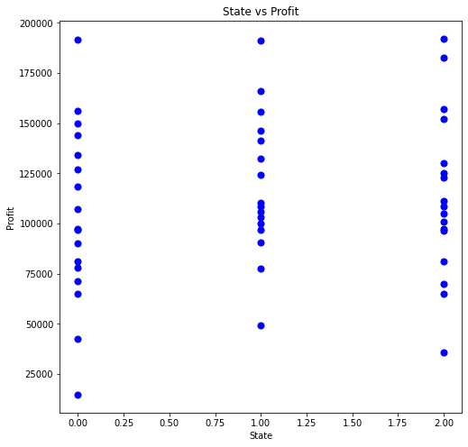

```python
plt.scatter(x1, y1, color='Blue', s=50)
plt.xlabel('State')
plt.ylabel('Profit')
plt.title('State vs Profit')
plt.show()
```

Since state does not shows correlation so we can not know does it affects or not.

# Feature Engineering

```python
from sklearn.linear_model import LinearRegression
```

```python
X = data[["R&D Spend", "Administration", "Marketing Spend", "State"]]
```

```python
Y = data["Profit"]
```

```python
X.head()
```

|  | R&D Spend | Administration | Marketing Spend | State |
| --- | --- | --- | --- | --- |
| 0 | 165349.20 | 136897.80 | 471784.10 | New York |
| 1 | 162597.70 | 151377.59 | 443898.53 | California |
| 2 | 153441.51 | 101145.55 | 407934.54 | Florida |
| 3 | 144372.41 | 118671.85 | 383199.62 | New York |
| 4 | 142107.34 | 91391.77 | 366168.42 | Florida |

```python
Y.head()
```

```
0    192261.83
1    191792.06
2    191050.39
3    182901.99
4    166187.94
Name: Profit, dtype: float64
```

Since "X" contains "State" which has strings, so we can not fit the data into the model. So, we need to do feature Engineering and transform/encode the data to new form. It can be done by converting the given labels into some numbers.

```python
states = X["State"]
```

```python
states
```

```
0       New York
1     California
2        Florida
3       New York
4        Florida
5       New York
6     California
7        Florida
8       New York
9     California
10       Florida
11    California
12       Florida
13    California
14       Florida
```

[output cut: 36 more lines]

## One Host Encoding

```python
temp_states = pd.get_dummies(states)
```

```python
temp_states.head()
```

|  | California | Florida | New York |
| --- | --- | --- | --- |
| 0 | 0 | 0 | 1 |
| 1 | 1 | 0 | 0 |
| 2 | 0 | 1 | 0 |
| 3 | 0 | 0 | 1 |
| 4 | 0 | 1 | 0 |

```python
final_states = temp_states.iloc[:,0:3]
```

```python
final_states.head()
```

|  | California | Florida | New York |
| --- | --- | --- | --- |
| 0 | 0 | 0 | 1 |
| 1 | 1 | 0 | 0 |
| 2 | 0 | 1 | 0 |
| 3 | 0 | 0 | 1 |
| 4 | 0 | 1 | 0 |

# Replacing Old Data with New Data

Replacing old data with new data that has catagorical data with new data values which we just created.

### Removing Old State column

```python
X = X.iloc[:,0:3]
```

```python
X.head()
```

|  | R&D Spend | Administration | Marketing Spend |
| --- | --- | --- | --- |
| 0 | 165349.20 | 136897.80 | 471784.10 |
| 1 | 162597.70 | 151377.59 | 443898.53 |
| 2 | 153441.51 | 101145.55 | 407934.54 |
| 3 | 144372.41 | 118671.85 | 383199.62 |
| 4 | 142107.34 | 91391.77 | 366168.42 |

```python
final_states.columns
```

```
Index(['California', 'Florida', 'New York'], dtype='object')
```

### Add the Encoded Columns

```python
X[["California","Florida","New York"]] = final_states
```

```python
X.head()
```

|  | R&D Spend | Administration | Marketing Spend | California | Florida | New York |
| --- | --- | --- | --- | --- | --- | --- |
| 0 | 165349.20 | 136897.80 | 471784.10 | 0 | 0 | 1 |
| 1 | 162597.70 | 151377.59 | 443898.53 | 1 | 0 | 0 |
| 2 | 153441.51 | 101145.55 | 407934.54 | 0 | 1 | 0 |
| 3 | 144372.41 | 118671.85 | 383199.62 | 0 | 0 | 1 |
| 4 | 142107.34 | 91391.77 | 366168.42 | 0 | 1 | 0 |

# Splitting the Dataset into Training and Testing Data

```python
from sklearn.model_selection import train_test_split
```

```python
X_train, X_test, y_train, y_test = train_test_split(X, Y, test_size=0.20, random_state=42)
```

# Creating the Model

```python
model = LinearRegression()
```

# Training the Model

```python
model.fit(X_train,y_train)
```

```
LinearRegression()
```

# Predicting using the Model

```python
y_pred=model.predict(X_test)
```

```python
y_pred
```

```
array([126362.87908255,  84608.45383633,  99677.49425146,  46357.46068582,
       128750.48288505,  50912.41741878, 109741.35032702, 100643.24281647,
        97599.27574593, 113097.42524431])
```

# Model Evaluation

```python
from sklearn.metrics import r2_score, mean_squared_error, mean_absolute_error
```

```python
r2Score = r2_score(y_pred, y_test)
print("R2 score of model is :" ,r2Score)
```

```
R2 score of model is : 0.8851366465093731
```

```python
mse = mean_squared_error(y_pred, y_test)
print("Mean Squarred Error is :" ,mse)
```

```
Mean Squarred Error is : 82010363.04423533
```

```python
rmse = np.sqrt(mean_squared_error(y_pred, y_test))
print("Root Mean Squarred Error is : ",rmse)
```

```
Root Mean Squarred Error is :  9055.957323454839
```

```python
mae = mean_absolute_error(y_pred,y_test)
print("Mean Absolute Error is :" ,mae)
```

```
Mean Absolute Error is : 6961.477813250242
```

# Prediction Summary for Profits

```python
model.coef_
```

```
array([ 8.05630064e-01, -6.87878823e-02,  2.98554429e-02, -3.15260255e+02,
        6.23532751e+02, -3.08272495e+02])
```

```python
print("Profit from R&D Spend: {RnDSpend}".format(RnDSpend = model.coef_[0]))
print("Profit from Administration: {Administration}".format(Administration = model.coef_[1]))
print("Profit from Marketing Spend: {MarketingSpend}".format(MarketingSpend = model.coef_[2]))
print("Profit from California: {California}".format(California = model.coef_[3]))
print("Profit from Florida: {Florida}".format(Florida = model.coef_[4]))
print("Profit from New York: {NewYork}".format(NewYork = model.coef_[5]))
```

```
Profit from R&D Spend: 0.8056300637152191
Profit from Administration: -0.06878788227682973
Profit from Marketing Spend: 0.029855442922689233
Profit from California: -315.2602553718063
Profit from Florida: 623.5327507766303
Profit from New York: -308.2724954048243
```